# nlzb43

## COMP42415 coursework 2024-25

### Data Preprocessing

1. Prepare the dataset by applying any pre-processing or cleaning steps that you consider as

necessary. Then, split the dataset into a training set containing 80% of the samples and a test set containing 20% of the samples. Follow an appropriate strategy for the split. You must use these training/test sets for all the models in this coursework.

```python
import re
import nltk
import pandas as pd
from nltk.corpus import stopwords
from nltk.stem import WordNetLemmatizer
from sklearn.feature_extraction.text import ENGLISH_STOP_WORDS, TfidfVectorizer

nltk.download('stopwords')
nltk.download('wordnet')

# These are negation or contrastive words.
# They carry important sentiment or semantic meaning and should NOT be removed as regular stopwords.
NEGATION_WORDS = {
    "not", "no", "never", "nothing", "nowhere", "hardly", "scarcely", "barely",
    "dont", "isnt", "didnt", "wasnt", "cant", "wont", "however", "but"
}

# Custom stopword list (excluding negation words)
custom_stop_words = set(ENGLISH_STOP_WORDS) - NEGATION_WORDS

# Text preprocessing function (supports negation emphasis and optional lemmatization)
def preprocess_text(text,
                    remove_stopwords=True,
                    use_lemmatization=True,
                    emphasize_negation=True):
    # Lowercase + remove punctuation and symbols
    text = str(text).lower()
    text = re.sub(r"[^a-z\s]", "", text)       # Keep only letters
    text = re.sub(r"\s+", " ", text).strip()   # Remove extra whitespaces

    # Tokenization
    tokens = text.split()

    # Remove stopwords (but keep negation words)
    if remove_stopwords:
        tokens = [word for word in tokens if word not in custom_stop_words]

    # Lemmatization (e.g., loved → love)
    if use_lemmatization:
        lemmatizer = WordNetLemmatizer()
        tokens = [lemmatizer.lemmatize(w) for w in tokens]

    # Emphasize negation (e.g., not → NOT_not)
    if emphasize_negation:
        tokens = ["NOT_" + w if w in NEGATION_WORDS else w for w in tokens]

    return " ".join(tokens)

# Load dataset
df = pd.read_csv("dataset.csv")

# Drop rows with missing text or score
df = df.dropna(subset=["Text"])
df = df.dropna(subset=["Score"])

# Apply preprocessing to text
df["Text_clean"] = df["Text"].apply(
    lambda x: preprocess_text(
        x,
        remove_stopwords=True,
        use_lemmatization=True,
        emphasize_negation=True
    )
)

# Display score distribution and first few samples
print(df["Score"].value_counts().sort_index())
print(df[["Text", "Text_clean"]].head())
```

```
Score
1.0     4405
2.0     3283
3.0     5129
4.0    10242
5.0    27774
Name: count, dtype: int64
                                                Text  \
0  It is a nice made necklace, and the butterfly ...
1  I bought this necklace on a whim; I love butte...
2  Bought via gold box ,it is much better than I ...
4  Love this butterfly pendant. Right size, high ...
5  I bought this as a graduation gift for my daug...

                                          Text_clean
0  nice necklace butterfly pendant look beautiful...
1  bought necklace whim love butterfly looked dai...
2      bought gold box better thoughtthe chain great
4  love butterfly pendant right size high quality...
5  bought graduation gift daughter wanted ring re...
```

```python
# Verify preprocessing by checking tokenization output
print(df["Text_clean"].iloc[36])
print(df["Text_clean"].iloc[36].split())
```

```
necklace beautiful picture convey chain strong NOT_dont worry breaking topaz gemstone perfect blue just elegant receive compliment time wear
['necklace', 'beautiful', 'picture', 'convey', 'chain', 'strong', 'NOT_dont', 'worry', 'breaking', 'topaz', 'gemstone', 'perfect', 'blue', 'just', 'elegant', 'receive', 'compliment', 'time', 'wear']
```

```
Average token count: 23.72163751893455
Minimum token count: 1
Maximum token count: 544
ring: 33743
NOT_but: 24372
NOT_not: 21360
look: 14702
like: 12321
earring: 11166
love: 10777
great: 10553
just: 10452
nice: 10344
wear: 9306
price: 8829
size: 8694
beautiful: 8557
bought: 8482
good: 7865
quality: 7547
really: 7536
chain: 7501
necklace: 7281
```

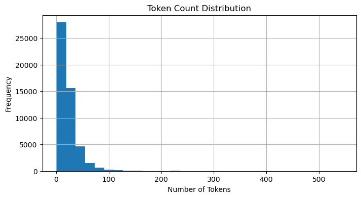

```python
# Perform token-level statistics to understand overall characteristics of cleaned text

from collections import Counter
import matplotlib.pyplot as plt

df["Text_tokens"] = df["Text_clean"].apply(lambda x: x.split())
df["Token_count"] = df["Text_tokens"].apply(len)

print("Average token count:", df["Token_count"].mean())
print("Minimum token count:", df["Token_count"].min())
print("Maximum token count:", df["Token_count"].max())

# Count most common words (top 20)
all_tokens = df["Text_tokens"].explode()
word_freq = Counter(all_tokens)
common_words = word_freq.most_common(20)
for word, count in common_words:
    print(f"{word}: {count}")

# Plot histogram of token count distribution
plt.figure(figsize=(8, 4))
df["Token_count"].hist(bins=30)
plt.title("Token Count Distribution")
plt.xlabel("Number of Tokens")
plt.ylabel("Frequency")
plt.grid(True)
plt.show()
```

### Split the dataset into training set and test set

```python
from sklearn.model_selection import train_test_split

# Text features and labels
X = df["Text_clean"]
y = df["Score"].astype(int)

# Split into training and testing sets (fixed ratio, stratified by class)
X_train, X_test, y_train, y_test = train_test_split(
    X, y,
    test_size=0.2,
    random_state=42,
    stratify=y
)

# Get train/test sizes
train_size = len(X_train)
test_size = len(X_test)
```

### Naïve Bayes model

2. Implement a Naïve Bayes model for predicting the rating of a product review. Train your model

on the training set and test it on the test set. Use an appropriate text representation.

```python
from sklearn.model_selection import train_test_split
from sklearn.pipeline import Pipeline
from sklearn.feature_extraction.text import TfidfVectorizer
from sklearn.naive_bayes import ComplementNB
from sklearn.metrics import accuracy_score, classification_report
from sklearn.metrics import confusion_matrix
from sklearn.metrics import ConfusionMatrixDisplay
import matplotlib.pyplot as plt
import joblib
import seaborn as sns
```

```
40666 10167 0.684961148814793
               precision  recall  f1-score    support
1                 0.487   0.792     0.603    881.000
2                 0.444   0.236     0.308    657.000
3                 0.473   0.374     0.418   1026.000
4                 0.532   0.436     0.479   2048.000
5                 0.820   0.870     0.844   5555.000
accuracy          0.685   0.685     0.685      0.685
macro avg         0.551   0.542     0.531  10167.000
weighted avg      0.674   0.685     0.672  10167.000
```

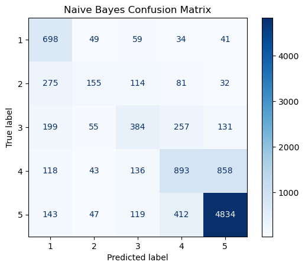

```python
# Build Naive Bayes pipeline
nb_pipeline = Pipeline([
    ('tfidf', TfidfVectorizer(
    max_features=20000,
    ngram_range=(1, 2),       # Use unigram + bigram
    min_df=2,                 # Remove rare words
)
),
    ('nb', ComplementNB())   # Suitable for multi-class & imbalanced datasets
])

# Train and predict
nb_pipeline.fit(X_train, y_train)
y_pred_nb = nb_pipeline.predict(X_test)
accuracy = accuracy_score(y_test, y_pred_nb)
report = classification_report(y_test, y_pred_nb, digits=3, output_dict=True)

# Save the model
joblib.dump(nb_pipeline, "nb_model.pkl")

# Format classification report
report_df = pd.DataFrame(report).transpose()
report_df = report_df[['precision', 'recall', 'f1-score', 'support']]
report_df = report_df.round(3)

print(train_size, test_size, accuracy, '\n', report_df)

# Generate confusion matrix
cm = confusion_matrix(y_test, y_pred_nb)
labels = sorted(y.unique())  # Ensure consistent label order

ConfusionMatrixDisplay.from_predictions(y_test, y_pred_nb, cmap='Blues')
plt.title("Naive Bayes Confusion Matrix")
plt.show()
```

### k-Nearest Neighbours model

3. Implement a k-Nearest Neighbours model for predicting the rating of a product review. Train your model on the training set and test it on the test set. Use an appropriate text representation. You must select the best k by examining the performance of the model for 𝑘 ∈ {1, 3, 5, 7, 9}, using an appropriate cross-validation approach. Create a plot for k vs. classification performance to justify your choice.

```python
from sklearn.model_selection import cross_val_score
from sklearn.neighbors import KNeighborsClassifier
from sklearn.metrics import accuracy_score
```

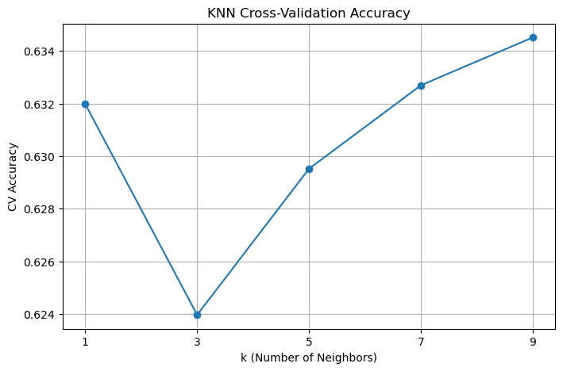

```
(9, 0.6345105926003792)
```

```python
# Convert sample text using TF-IDF
# Text vectorization
tfidf_vectorizer = TfidfVectorizer(
    max_features=20000,
    ngram_range=(1, 2),       # Use unigram + bigram
    min_df=2,)                # Filter out rare terms
X_train_vec = tfidf_vectorizer.fit_transform(X_train)

# Define candidate k values
k_values = [1, 3, 5, 7, 9]
cv_scores = []

# Perform 5-fold cross-validation for each k
for k in k_values:
    knn = KNeighborsClassifier(n_neighbors=k)
    scores = cross_val_score(knn, X_train_vec, y_train, cv=5, scoring='accuracy')
    cv_scores.append(scores.mean())

#Plot cross-validation results
plt.figure(figsize=(8, 5))
plt.plot(k_values, cv_scores, marker='o')
plt.title("KNN Cross-Validation Accuracy")
plt.xlabel("k (Number of Neighbors)")
plt.ylabel("CV Accuracy")
plt.grid(True)
plt.xticks(k_values)
plt.show()

# Return best k and its corresponding accuracy
best_k = k_values[cv_scores.index(max(cv_scores))]
best_score = max(cv_scores)
best_k, best_score
```

```
0.6350939313465133
               precision  recall  f1-score    support
1                 0.557   0.440     0.492    881.000
2                 0.437   0.207     0.281    657.000
3                 0.503   0.269     0.350   1026.000
4                 0.511   0.235     0.322   2048.000
5                 0.675   0.932     0.783   5555.000
accuracy          0.635   0.635     0.635      0.635
macro avg         0.536   0.417     0.446  10167.000
weighted avg      0.599   0.635     0.589  10167.000
```

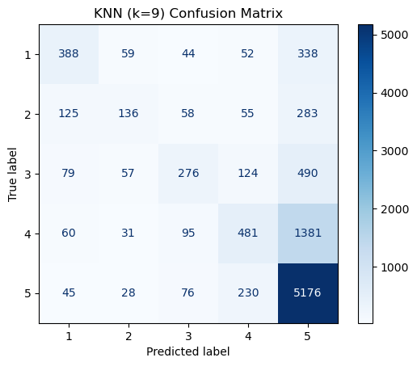

```python
# Build and train KNN model
knn_pipeline = Pipeline([
    ('tfidf', TfidfVectorizer(
    max_features=20000,
    ngram_range=(1, 2),
    stop_words='english',
    min_df=2,)),
    ('knn', KNeighborsClassifier(n_neighbors=9))
])

# Train the model and make predictions
knn_pipeline.fit(X_train, y_train)
y_pred_knn = knn_pipeline.predict(X_test)
accuracy_knn = accuracy_score(y_test, y_pred_knn)
report_knn = classification_report(y_test, y_pred_knn, digits=3, output_dict=True)

# Save the model
joblib.dump(knn_pipeline, "knn_model.pkl")

# Format classification report
report_knn_df = pd.DataFrame(report_knn).transpose()
report_knn_df = report_knn_df[['precision', 'recall', 'f1-score', 'support']]
report_knn_df = report_knn_df.round(3)

print(accuracy_knn,'\n', report_knn_df)

# Plot confusion matrix
ConfusionMatrixDisplay.from_predictions(y_test, y_pred_knn, cmap='Blues')
plt.title("KNN (k=9) Confusion Matrix")
plt.show()
```

### Convolutional Neural Network (CNN)

4. Implement a Convolutional Neural Network (CNN) model for predicting the rating of a product review. The model must have at least two convolutional layers. Train your model on the training set and test it on the test set. Use an appropriate text representation.

```python
from tensorflow.keras.preprocessing.text import Tokenizer
from tensorflow.keras.preprocessing.sequence import pad_sequences
from tensorflow.keras.models import Sequential
from tensorflow.keras.layers import Embedding, Conv1D, MaxPooling1D, GlobalMaxPooling1D, Dense
import numpy as np
import pickle
from tensorflow.keras.callbacks import EarlyStopping
from tensorflow.keras.utils import to_categorical
```

```
286/286 - 14s - 51ms/step - accuracy: 0.6059 - loss: 1.0032 - val_accuracy: 0.6754 - val_loss: 0.8122
286/286 - 14s - 50ms/step - accuracy: 0.7187 - loss: 0.7112 - val_accuracy: 0.7022 - val_loss: 0.7637
286/286 - 15s - 52ms/step - accuracy: 0.7845 - loss: 0.5532 - val_accuracy: 0.7057 - val_loss: 0.8241
286/286 - 15s - 53ms/step - accuracy: 0.8489 - loss: 0.4046 - val_accuracy: 0.6890 - val_loss: 0.9052
318/318 ━━━━━━━━━━━━━━━━━━━━ 1s 5ms/step
Accuracy (CNN): 0.7038457755483427
              precision  recall  f1-score    support
1                 0.575   0.767     0.657    881.000
2                 0.446   0.187     0.264    657.000
3                 0.514   0.370     0.431   1026.000
4                 0.558   0.417     0.477   2048.000
5                 0.795   0.922     0.854   5555.000
accuracy          0.704   0.704     0.704      0.704
macro avg         0.577   0.533     0.537  10167.000
weighted avg      0.677   0.704     0.680  10167.000
```

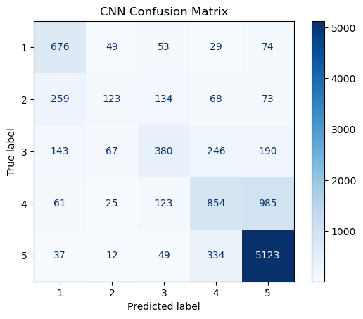

```python
# Data preprocessing: Tokenization + Padding
tokenizer = Tokenizer(num_words=20000)
tokenizer.fit_on_texts(X_train)

# Convert text to sequences and pad to uniform length
X_train_seq = tokenizer.texts_to_sequences(X_train)
X_test_seq = tokenizer.texts_to_sequences(X_test)

max_len = 200
X_train_pad = pad_sequences(X_train_seq, maxlen=max_len)
X_test_pad = pad_sequences(X_test_seq, maxlen=max_len)

# One-hot encode the labels (Note: subtract 1 because one-hot starts from 0)
y_train_cat = to_categorical(y_train - 1, num_classes=5)
y_test_cat = to_categorical(y_test - 1, num_classes=5)

# Build CNN model
model_cnn = Sequential()
model_cnn.add(Embedding(input_dim=20000, output_dim=128))   # Word embedding layer
model_cnn.add(Conv1D(128, 5, activation='relu'))            # Convolution layer
model_cnn.add(MaxPooling1D(pool_size=2))
model_cnn.add(Conv1D(64, 5, activation='relu'))
model_cnn.add(GlobalMaxPooling1D())                         # Global pooling
model_cnn.add(Dense(64, activation='relu'))
model_cnn.add(Dense(5, activation='softmax'))               # Output layer (5 classes)

# Compile the model
model_cnn.compile(
    loss='categorical_crossentropy',
    optimizer='adam',
    metrics=['accuracy']
)

# Use EarlyStopping to prevent overfitting
early_stop = EarlyStopping(
    monitor='val_loss',
    patience=2,
    restore_best_weights=True
)

# Train CNN model
model_cnn.fit(
    X_train_pad, y_train_cat,
    epochs=5,
    batch_size=128,
    validation_split=0.1,
    callbacks=[early_stop],
    verbose=2
)

# Prediction and evaluation
y_pred = model_cnn.predict(X_test_pad)
y_pred_classes_cnn = np.argmax(y_pred, axis=1) + 1     # Add 1 to match original labels (1–5)
acc_cnn = accuracy_score(y_test, y_pred_classes_cnn)
report_cnn = classification_report(y_test, y_pred_classes_cnn, digits=3, output_dict=True)

# Format classification report
df_report_cnn = pd.DataFrame(report_cnn).transpose()
df_report_cnn = df_report_cnn[['precision', 'recall', 'f1-score', 'support']]
df_report_cnn = df_report_cnn.round(3)

print("Accuracy (CNN):", acc_cnn)
print(df_report_cnn)

# Save model and tokenizer
model_cnn.save("cnn_model.keras")
with open("tokenizer_cnn.pkl", "wb") as f:
    pickle.dump(tokenizer, f)

# Show confusion matrix
ConfusionMatrixDisplay.from_predictions(y_test, y_pred_classes_cnn, cmap='Blues')
plt.title("CNN Confusion Matrix")
plt.show()
```

### Long Short-Term Memory (LSTM)

5. Implement a Recurrent Neural Network (RNN) or a Long Short-Term Memory (LSTM) model for predicting the rating of a product review. The model must have at least two RNN/LSTM layers. Train your model on the training set and test it on the test set. Use an appropriate text representation.

```python
from tensorflow.keras.layers import LSTM
from tensorflow.keras.layers import Embedding, LSTM, Dense, Dropout
from tensorflow.keras.utils import to_categorical
from sklearn.utils import class_weight
```

```
286/286 - 41s - 142ms/step - accuracy: 0.5343 - loss: 1.2577 - val_accuracy: 0.5744 - val_loss: 1.0443
286/286 - 40s - 138ms/step - accuracy: 0.6520 - loss: 0.9758 - val_accuracy: 0.6523 - val_loss: 0.8671
286/286 - 39s - 137ms/step - accuracy: 0.7051 - loss: 0.8201 - val_accuracy: 0.6592 - val_loss: 0.8821
286/286 - 39s - 137ms/step - accuracy: 0.7513 - loss: 0.6881 - val_accuracy: 0.6299 - val_loss: 0.9585
318/318 ━━━━━━━━━━━━━━━━━━━━ 5s 16ms/step
Accuracy (LSTM): 0.6480771122258286
              precision  recall  f1-score    support
1                 0.617   0.669     0.642    881.000
2                 0.365   0.432     0.396    657.000
3                 0.399   0.442     0.420   1026.000
4                 0.443   0.532     0.483   2048.000
5                 0.863   0.751     0.803   5555.000
accuracy          0.648   0.648     0.648      0.648
macro avg         0.537   0.565     0.549  10167.000
weighted avg      0.678   0.648     0.660  10167.000
```

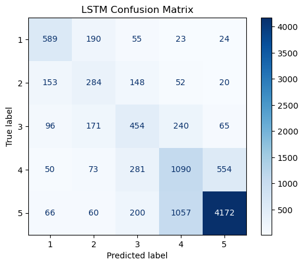

```python
# Keep original score range (1 to 5)
y = df["Score"].astype(int)


# One-hot encode the labels
y_train_cat = to_categorical(y_train - 1, num_classes=5)
y_test_cat = to_categorical(y_test - 1, num_classes=5)

# Handle class imbalance by computing class weights
weights = class_weight.compute_class_weight(
    class_weight="balanced",
    classes=np.unique(y_train),
    y=y_train
)
class_weight_dict = {i: w for i, w in enumerate(weights)}

# Build LSTM model
model_lstm = Sequential()
model_lstm.add(Embedding(input_dim=20000, output_dim=128))
model_lstm.add(LSTM(64, return_sequences=True))
model_lstm.add(LSTM(32))
model_lstm.add(Dense(64, activation='relu'))
model_lstm.add(Dropout(0.3))
model_lstm.add(Dense(5, activation='softmax'))

# Compile the model
model_lstm.compile(
    loss='categorical_crossentropy',
    optimizer='adam',
    metrics=['accuracy']
)

# Use EarlyStopping to avoid overfitting
early_stop = EarlyStopping(
    monitor='val_loss',
    patience=2,
    restore_best_weights=True
)

# Train the LSTM model
model_lstm.fit(
    X_train_pad, y_train_cat,
    epochs=5, batch_size=128,
    validation_split=0.1,
    callbacks=[early_stop],
    verbose=2,
    class_weight=class_weight_dict
)

# Prediction and evaluation
y_pred = model_lstm.predict(X_test_pad)
y_pred_classes_lstm = np.argmax(y_pred, axis=1) + 1
y_true = y_test
acc_lstm = accuracy_score(y_true, y_pred_classes_lstm)
report_lstm = classification_report(y_true, y_pred_classes_lstm, digits=3, output_dict=True)

# Format classification report
df_report_lstm = pd.DataFrame(report_lstm).transpose()
df_report_lstm = df_report_lstm[['precision', 'recall', 'f1-score', 'support']]
df_report_lstm = df_report_lstm.round(3)
df_report_lstm

print("Accuracy (LSTM):", acc_lstm)
print(df_report_lstm)

# Save model and tokenizer
model_lstm.save("lstm_model.keras")
with open("tokenizer_lstm.pkl", "wb") as f:
    pickle.dump(tokenizer, f)

# Show confusion matrix
ConfusionMatrixDisplay.from_predictions(y_test, y_pred_classes_lstm, cmap='Blues')
plt.title("LSTM Confusion Matrix")
plt.show()
```

### Evaluation Metrics and Confusion Matrix Analysis

6. Compute the confusion matrix, accuracy, F1-score, precision and recall for each model.

```
=== Naive Bayes ===
Accuracy : 0.685
Precision: 0.674
Recall   : 0.685
F1-Score : 0.672
```

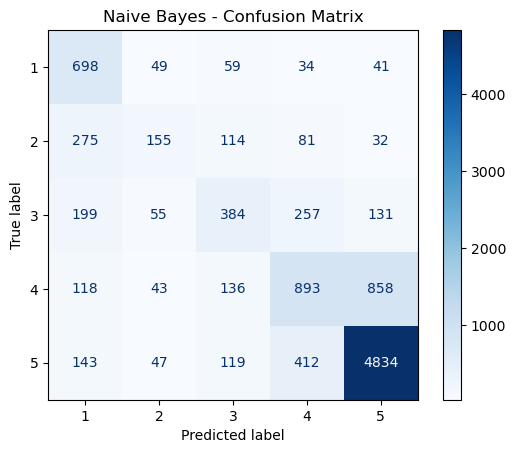

```
=== KNN ===
Accuracy : 0.635
Precision: 0.599
Recall   : 0.635
F1-Score : 0.589
```

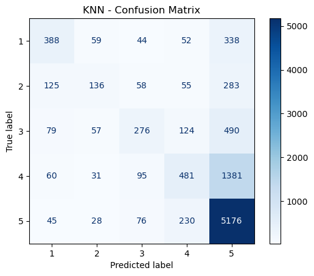

```
=== CNN ===
Accuracy : 0.704
Precision: 0.677
Recall   : 0.704
F1-Score : 0.680
```

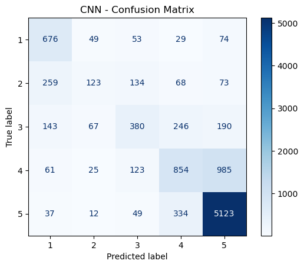

```
=== LSTM ===
Accuracy : 0.648
Precision: 0.678
Recall   : 0.648
F1-Score : 0.660
```

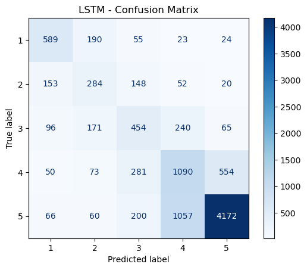

```
         Model  Accuracy  Precision  Recall  F1-Score
0  Naive Bayes     0.685      0.674   0.685     0.672
1          KNN     0.635      0.599   0.635     0.589
2          CNN     0.704      0.677   0.704     0.680
3         LSTM     0.648      0.678   0.648     0.660
```

```python
from sklearn.metrics import accuracy_score, precision_score, recall_score, f1_score, confusion_matrix

def evaluate_model(name, y_true, y_pred):
    accuracy = accuracy_score(y_true, y_pred)
    precision = precision_score(y_true, y_pred, average='weighted', zero_division=0)
    recall = recall_score(y_true, y_pred, average='weighted', zero_division=0)
    f1 = f1_score(y_true, y_pred, average='weighted', zero_division=0)
    cm = confusion_matrix(y_true, y_pred)

    print(f"\n=== {name} ===")
    print(f"Accuracy : {accuracy:.3f}")
    print(f"Precision: {precision:.3f}")
    print(f"Recall   : {recall:.3f}")
    print(f"F1-Score : {f1:.3f}")

    # Plot confusion matrix
    ConfusionMatrixDisplay.from_predictions(y_true, y_pred, cmap='Blues')
    plt.title(f"{name} - Confusion Matrix")
    plt.show()

    return {
        "Model": name,
        "Accuracy": round(accuracy, 3),
        "Precision": round(precision, 3),
        "Recall": round(recall, 3),
        "F1-Score": round(f1, 3)
    }

# Store results from each model
results = []

results.append(evaluate_model("Naive Bayes", y_test, y_pred_nb))
results.append(evaluate_model("KNN", y_test, y_pred_knn))
results.append(evaluate_model("CNN", y_test, y_pred_classes_cnn))
results.append(evaluate_model("LSTM", y_test, y_pred_classes_lstm))

# Display results as a summary table
df_results = pd.DataFrame(results)
print(df_results)
```

This step shows not only how accurate the models are, but also how efficient they are—helping justify model selection from both a performance and a deployment perspective.

```python
import time

# Measure prediction time for a model
def timed_prediction(model, X_input, is_neural=False):
    start = time.time()

    if is_neural:
        y_pred = model.predict(X_input)
        y_pred = np.argmax(y_pred, axis=1) + 1  # # Neural model: convert probabilities to class labels (1–5)
    else:
        y_pred = model.predict(X_input)

    end = time.time()
    elapsed = round(end - start, 3)
    return y_pred, elapsed

# Measure prediction time for each model
# Naive Bayes
y_pred_nb, t_nb = timed_prediction(nb_pipeline, X_test)
# KNN
y_pred_knn, t_knn = timed_prediction(knn_pipeline, X_test)
# CNN
y_pred_cnn, t_cnn = timed_prediction(model_cnn, X_test_pad, is_neural=True)
# LSTM
y_pred_lstm, t_lstm = timed_prediction(model_lstm, X_test_pad, is_neural=True)

# Add prediction time to the results table
df_results["Time (s)"] = [t_nb, t_knn, t_cnn, t_lstm]
print(df_results.sort_values("F1-Score", ascending=False))
```

```
318/318 ━━━━━━━━━━━━━━━━━━━━ 1s 4ms/step
318/318 ━━━━━━━━━━━━━━━━━━━━ 5s 16ms/step
         Model  Accuracy  Precision  Recall  F1-Score  Time (s)
2          CNN     0.704      0.677   0.704     0.680     1.230
0  Naive Bayes     0.685      0.674   0.685     0.672     0.247
3         LSTM     0.648      0.678   0.648     0.660     5.101
1          KNN     0.635      0.599   0.635     0.589     7.825
```

### Model Saving, Loading, and Unified Inference Function

7. Store the four trained models in files and implement a function “predict_product_rating(text, model)” that given a text string (“text”) and model filename (“model”), it will load the pre-trained model, and predict the product review rating of the input text. The function should be able to work without requiring to rerun all or part of your code.

```python
from tensorflow.keras.models import load_model
from tensorflow.keras.preprocessing.sequence import pad_sequences

# Preprocess input text (for CNN / LSTM models)
def preprocess_input(text, tokenizer, max_len=200):
    seq = tokenizer.texts_to_sequences([text])
    return pad_sequences(seq, maxlen=max_len)

# General prediction function: supports four model types
def predict_product_rating(text, model_filename):
    if model_filename.endswith(".pkl"):
        # Traditional ML models: Naive Bayes / KNN
        model = joblib.load(model_filename)
        return int(model.predict([text])[0])

    elif model_filename.endswith(".keras"):
        # Deep learning models: CNN / LSTM
        model_type = model_filename.split("_")[0]    # 'cnn' or 'lstm'
        tokenizer_path = f"tokenizer_{model_type}.pkl"

        # Load tokenizer
        with open(tokenizer_path, "rb") as f:
            tokenizer = pickle.load(f)

        # Preprocess input and load model
        x_input = preprocess_input(text, tokenizer)
        model = load_model(model_filename)
        prob = model.predict(x_input)

        # Choose the class with highest probability (+1 to match label range 1–5)
        return int(np.argmax(prob, axis=1)[0] + 1)

    else:
        raise ValueError("Unsupported model file type: " + model_filename)

# Predict using all four models at once
def predict_with_all_models(text):
    models = [
        ("Naive Bayes", "nb_model.pkl"),
        ("KNN", "knn_model.pkl"),
        ("CNN", "cnn_model.keras"),
        ("LSTM", "lstm_model.keras")
    ]

    print(f"\n Input text for prediction：\"{text}\"\n")
    for name, model_file in models:
        try:
            rating = predict_product_rating(text, model_file)
            print(f"[{name}] → Predicted rating：{rating}")
        except Exception as e:
            print(f"[{name}] → Error occurred：{e}")

# Interactive prediction loop
while True:
    text_input = input("\n Enter product review text (type 'quit' to exit)：\n")

    if text_input.strip().lower() == "quit":
        print(" Prediction ended ")
        break

    predict_with_all_models(text_input)
```

```
 Input text for prediction："This is made OK. The stones are washed out, no color"

[Naive Bayes] → Predicted rating：3
[KNN] → Predicted rating：3
1/1 ━━━━━━━━━━━━━━━━━━━━ 0s 26ms/step
[CNN] → Predicted rating：2
1/1 ━━━━━━━━━━━━━━━━━━━━ 0s 73ms/step
[LSTM] → Predicted rating：3
```

```
 Input text for prediction："Absolutely beautiful and great quality, I love it"

[Naive Bayes] → Predicted rating：5
[KNN] → Predicted rating：5
1/1 ━━━━━━━━━━━━━━━━━━━━ 0s 26ms/step
[CNN] → Predicted rating：5
1/1 ━━━━━━━━━━━━━━━━━━━━ 0s 74ms/step
[LSTM] → Predicted rating：5
```

```
 Prediction ended
```

### Written Report

#### Introduction of the Dataset

The dataset comprises 59,621 entries featuring two critical columns: Score and Text, which represent product review ratings and the corresponding feedback. While it holds significant potential for text classification tasks, it presents several challenges that must be addressed for optimal results.

Moreover, the variability inherent in user-generated content—ranging from differences in text length to the use of informal language—coupled with potential noise from typos or irrelevant information, further complicates the task at hand. These factors reinforce the necessity for meticulous preprocessing and thoughtful handling to ensure that model performance is strong and fair across all rating categories.

Addressing these issues not only enhances the quality of the analysis but also ensures more equitable outcomes across diverse reviews, ultimately leading to more reliable insights.

#### Data Preparation

Effected data preparation is essential for building robust and accurate text classification models. This project carefully applied several preprocessing steps to clean, normalize, and transform the review text data into formats suitable for both traditional machine learning and deep learning models.

The text data was first standardized by converting all characters to lowercase and removing unwanted characters such as punctuation, digits, and excessive whitespace. This ensured uniformity and reduced noise in the input features.Stopwords were removed to eliminate commonly occurring but semantically weak words (e.g., "the", "and" and "is"). However, negation-related words (e.g., "not", "never", "but") were explicitly retained and emphasized using a custom prefix (e.g., "NOT_not"). This enhancement was important for preserving sentiment-reversing constructs that strongly influence meaning. Lemmatization was applied using WordNet, reducing inflected words to their base forms (e.g., "running" → "run"), thereby minimizing vocabulary size and improving generalization.

Next, the cleaned text was tokenized. For traditional models, the TfidfVectorizer was used with a unigram and bigram range, enabling the model to learn not only individual word importance but also short phrase patterns. A maximum of 20,000 features was specified to maintain computational efficiency while capturing primary information. For deep learning models such as CNN and LSTM, Keras's Tokenizer converted text into sequences of integers based on word indices. These sequences were then padded to a fixed length (200 tokens) to ensure uniform input dimensions, which is required for neural networks.

The target labels (scores ranging from 1 to 5) were one-hot encoded to match the format expected by categorical loss functions in deep learning. Furthermore, due to class imbalance (e.g., overrepresentation of score 5 and underrepresentation of scores 1 and 2), class weights were computed and applied during LSTM training to ensure fair learning across all classes.

These preprocessing steps were carefully selected and justified based on best practices in natural language processing. They collectively enhanced the model's ability to learn meaningful patterns, handle noisy or imbalanced data, and generalize well to unseen text (Kusumaningrum & Nugroho, 2017).

#### Machine Learning Method

This project explores four different machine learning architectures for multi-class text classification: Complement Naive Bayes (CNB), k-Nearest Neighbors (KNN), Convolutional Neural Networks (CNN), and Long Short-Term Memory (LSTM) networks. All models use either TF-IDF or word embeddings as the foundation for text representation, enabling them to process and learn from textual input effectively.

The Complement Naive Bayes (CNB) model is implemented within a TF-IDF-based pipeline to overcome the limitations of traditional Naive Bayes, particularly its sensitivity to class imbalance and strong feature independence assumptions. TF-IDF represents text with unigrams and bigrams, while rare terms are removed using a minimum document frequency threshold (Rennie et al., 2003).

The k-Nearest Neighbors (KNN) model utilizes TF-IDF features and classifies texts based on the majority class of the nearest neighbours in vector space. This architecture closely follows the methodology proposed by (Trstenjak et al., 2014), who demonstrated the effectiveness of combining KNN with TF-IDF representations for textual data. Several values of k are tested through cross-validation, with the best result achieved at k = 9. The final accuracy reached approximately 63.5%, making KNN a simple and interpretable model, though less robust when dealing with sparse or imbalanced data.

The Long Short-Term Memory (LSTM) model processes tokenized and padded text sequences using stacked LSTM layers, allowing it to capture sequential and contextual relationships between words. A dense layer and dropout are included to improve generalization and reduce overfitting. Initially, during training, the model exhibited biased behaviour due to a strong class imbalance in the dataset, where a large portion of samples was labelled as score 5. This led the model to predict a score of 5 for most inputs, regardless of actual content, resulting in poor performance and lack of sensitivity to other classes. To correct this, class weights were computed and incorporated into the training process, assigning higher importance to underrepresented classes. This allowed the model to better learn from all score categories and reduced its over-reliance on the dominant class. Early stopping was also used to retain the best weights and avoid overfitting. After applying these techniques, the model achieved an accuracy of 65%, and in the final integrated system, it demonstrated a significantly improved ability to interpret input text and assign appropriate categories, reflecting a more balanced and effective learning outcome (Hochreiter & Schmidhuber, 1997).

Each model was implemented using Keras or Scikit-learn. For the neural models, padding length was fixed at 200 tokens, and embedding layers were initialized with a vocabulary size of 20,000 and output dimensions of 128. The CNN and LSTM architectures used ReLU activation and categorical cross-entropy loss, optimized using the Adam optimizer (Kingma & Ba, 2015). Early stopping with a patience of 2 was used to prevent overfitting by halting training once the validation performance stopped improving. In the TF-IDF-based pipelines, the n-gram range was set to (1,2) and min_df = 2 to filter out noise while preserving functional co-occurrence patterns. These text representation choices helped enhance the model's ability to capture semantic meaning and improve generalization.

In addition to designing and training the models, the system also includes a set of utility functions to evaluate model performance and runtime efficiency. Each model’s predictions were assessed using weighted accuracy, precision, recall, and F1-score, along with confusion matrix visualization. A timing function was also implemented to compare prediction latency across models, revealing trade-offs between accuracy and speed—where Naive Bayes was the fastest and CNN achieved the highest F1 score.

A unified prediction interface was developed to support all four model types and improve usability and deployment readiness. Depending on the file format, the system automatically loads the appropriate model and tokenizer, preprocesses user input, and returns a predicted rating. An interactive command-line loop enables real-time testing of all models on arbitrary review inputs. These design choices strongly focus on practical evaluation, model comparison, and extensibility of the overall text classification framework.

#### Discussion

The overall results highlight that CNN achieved the best balance of accuracy and F1-score, while Naive Bayes performed well as a fast and lightweight baseline. However, several limitations should be noted. First, class imbalance negatively impacted predictions for minority classes, particularly scores 2 and 3, which consistently showed lower recall and F1 scores. Although class weighting helped slightly in the LSTM model, it did not fully resolve the issue. Second, models often confused adjacent ratings, such as predicting 4 as 5, familiar in ordinal classification where class boundaries are subtle and subjective.

#### References

Hochreiter, S., & Schmidhuber, J. (1997). Long short-term memory. Neural Computation, 9(8), 1735–1780. https://doi.org/10.1162/neco.1997.9.8.1735

Kim, Y. (2014). Convolutional neural networks for sentence classification. arXiv preprint arXiv:1408.5882. https://arxiv.org/abs/1408.5882

Kingma, D. P., & Ba, J. (2015). Adam: A method for stochastic optimization. In Proceedings of the 3rd International Conference on Learning Representations (ICLR). https://arxiv.org/abs/1412.6980

Kusumaningrum, R., & Nugroho, L. E. (2017). Preprocessing techniques for text mining. Retrieved from https://d1wqtxts1xzle7.cloudfront.net/54879053/PreprocessingTechniquesforTextMining-libre.pdf

Rennie, J. D., Shih, L., Teevan, J., & Karger, D. R. (2003). Tackling the poor assumptions of naive bayes text classifiers. In Proceedings of the 20th International Conference on Machine Learning (ICML-03), 616-623.

Trstenjak, B., Mikac, S., & Donko, D. (2014). KNN with TF-IDF based framework for text categorization. Procedia Engineering, 69, 1356–1364. https://doi.org/10.1016/j.proeng.2014.03.129